# Czas_Dostawy_Projekt

Filip Kosiorowski

2025-06-12

### W ramach projektu zbudowano i przeanalizowano sieć bayesowską opisującą zależności pomiędzy czynnikami wpływającymi na czas dostawy w usługach logistycznych. Wykorzystano dane dotyczące m.in. warunków pogodowych, dystansu, poziomu ruchu drogowego, typu pojazdu i doświadczenia kuriera. Dane zostały uprzednio poddane faktoryzacji i dyskretyzacji, a następnie zastosowano metody heurystyczne (Hill-Climbing) do uczenia struktury sieci z zastosowaniem blacklisty i whitelisty.

```r
# Wczytanie danych oraz wybór istotnych cech
# W ramach analizy przeprowadzono budowę oraz ocenę modeli sieci bayesowskich na podstawie danych dotyczących czasu dostaw.
# Celem analizy było zbadanie zależności pomiędzy cechami związanymi z dostawą a jej czasem.

dane <- read_csv("Food_Delivery_Times.csv", show_col_types = FALSE)

# Wybór istotnych cech do analizy
cechy <- c("Distance_km", "Weather", "Traffic_Level", "Time_of_Day",
           "Vehicle_Type", "Courier_Experience_yrs", "Delivery_Time_min")
dane <- dane %>% select(all_of(cechy)) %>% na.omit()

# Faktoryzacja i dyskretyzacja danych
# Wybrane cechy poddano dyskretyzacji, a następnie przekształcono je na zmienne kategoryczne
# Każdą zmienną liczbową przekształcamy na kategorie dyskretne, zmienne binarne zamieniamy na faktory

dane <- dane %>%
  mutate(
    Weather = factor(Weather),
    Traffic_Level = factor(Traffic_Level),
    Time_of_Day = factor(Time_of_Day),
    Vehicle_Type = factor(Vehicle_Type),
    Doświadczenie = cut(Courier_Experience_yrs, breaks = c(-Inf,1,3,Inf),
                        labels = c("niskie", "średnie", "wysokie")),
    Czas_Dostawy = cut(Delivery_Time_min, breaks = c(-Inf,20,40,Inf),
                      labels = c("krótki", "średni", "długi")),
    Dystans = cut(Distance_km, breaks = c(-Inf,2,5,Inf),
                 labels = c("blisko", "średnio", "daleko"))
  ) %>%
  select(Weather, Traffic_Level, Time_of_Day, Vehicle_Type,
         Doświadczenie, Czas_Dostawy, Dystans) %>%
  mutate(across(everything(), as.factor)) %>%
  droplevels() %>%
  na.omit()

dane_final <- as.data.frame(dane)
```

```r
# Uczenie struktury sieci bayesowskiej z blacklistą
# Wymuszamy, aby zmienna Czas_Dostawy nie była rodzicem żadnej innej zmiennej
# Dzięki temu analizujemy wpływ innych cech na czas dostawy

nodes <- names(dane_final)
blacklist <- data.frame(
  from = "Czas_Dostawy",
  to = setdiff(nodes, "Czas_Dostawy"),
  stringsAsFactors = FALSE
)

struktura <- hc(dane_final, blacklist = blacklist)
print(arcs(struktura))
```

```
##      from      to
## [1,] "Dystans" "Czas_Dostawy"
```

```r
model <- bn.fit(struktura, data = dane_final)
```

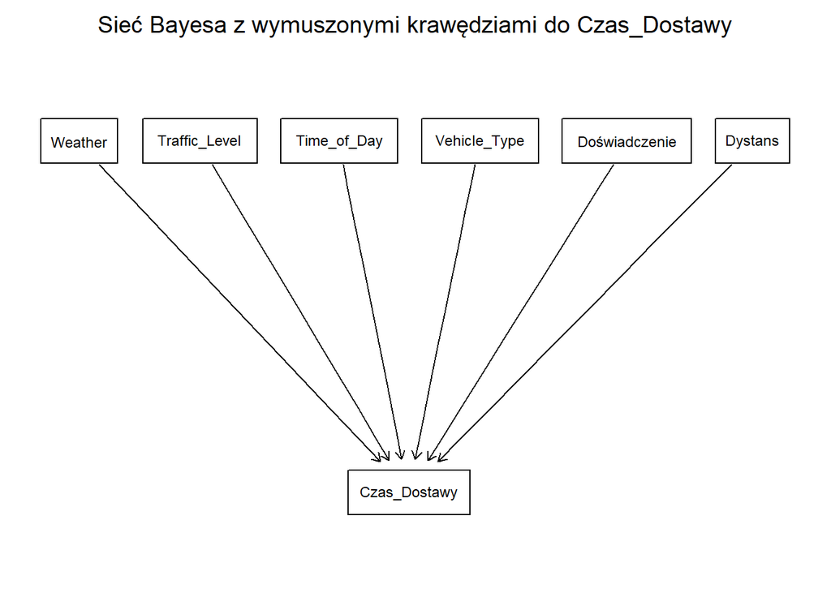

```r
# Wymuszenie krawędzi przychodzących do Czas_Dostawy — whitelist
# Zastosowano algorytm uczenia struktury z listą dozwolonych krawędzi, które wskazują na Czas_Dostawy jako zmienną zależną

nodes <- names(dane_final)
other_nodes <- setdiff(nodes, "Czas_Dostawy")

whitelist <- data.frame(
  from = other_nodes,
  to = rep("Czas_Dostawy", length(other_nodes)),
  stringsAsFactors = FALSE
)

blacklist <- data.frame(
  from = "Czas_Dostawy",
  to = other_nodes,
  stringsAsFactors = FALSE
)

struktura <- hc(dane_final, whitelist = whitelist, blacklist = blacklist)
graphviz.plot(struktura, main = "Sieć Bayesa z wymuszonymi krawędziami do Czas_Dostawy")
```

```r
print(arcs(struktura))
```

```
##      from            to
## [1,] "Weather"       "Czas_Dostawy"
## [2,] "Traffic_Level" "Czas_Dostawy"
## [3,] "Time_of_Day"   "Czas_Dostawy"
## [4,] "Vehicle_Type"  "Czas_Dostawy"
## [5,] "Doświadczenie" "Czas_Dostawy"
## [6,] "Dystans"       "Czas_Dostawy"
```

```r
# Ocena modelu za pomocą miary BIC
score_value <- score(struktura, data = dane_final, type = "bic")
print(score_value)
```

```
## [1] -16827.35
```

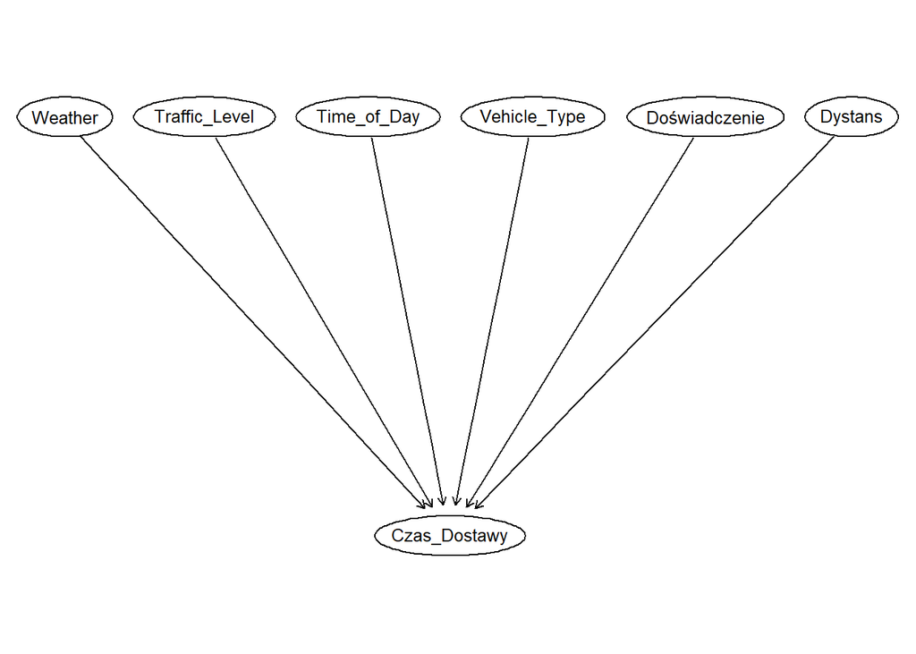

```r
# Wizualizacja sieci
graphviz.plot(struktura, layout = "dot", shape = "ellipse")
```

```r
# Wykres siły połączeń
strength <- arc.strength(struktura, data = dane_final)
print(strength)
```

```
##            from           to strength
## 1       Weather Czas_Dostawy 8701.905
## 2 Traffic_Level Czas_Dostawy 7249.691
## 3   Time_of_Day Czas_Dostawy 8153.021
## 4  Vehicle_Type Czas_Dostawy 7251.389
## 5 Doświadczenie Czas_Dostawy 7266.842
## 6       Dystans Czas_Dostawy 7125.404
```

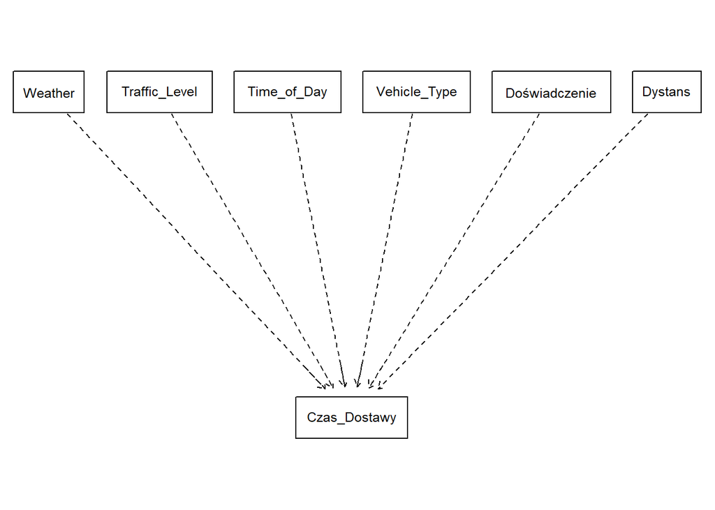

```r
strength.plot(struktura, strength = strength)
```

```r
# Testy niezależności warunkowej pomiędzy wybranymi zmiennymi
# Tworzona jest osobna macierz p-wartości dla każdej zmiennej Z,
# dla której testujemy niezależność pomiędzy parami pozostałych zmiennych z warunkowaniem na Z.
ci.test("Czas_Dostawy", "Vehicle_Type", data = dane_final)
```

[output not shown]

```
##
##  Mutual Information (disc.)
##
## data:  Czas_Dostawy ~ Vehicle_Type
## mi = 1.6303, df = 4, p-value = 0.8033
## alternative hypothesis: true value is greater than 0
```

```r
ci.test("Dystans", "Doświadczenie", data = dane_final)
```

```
##
##  Mutual Information (disc.)
##
## data:  Dystans ~ Doświadczenie
## mi = 1.2743, df = 4, p-value = 0.8657
## alternative hypothesis: true value is greater than 0
```

```r
ci.test("Czas_Dostawy", "Traffic_Level", z = "Time_of_Day", data = dane_final)
```

```
##
##  Mutual Information (disc.)
##
## data:  Czas_Dostawy ~ Traffic_Level | Time_of_Day
## mi = 29.017, df = 16, p-value = 0.02382
## alternative hypothesis: true value is greater than 0
```

```r
ci.test("Czas_Dostawy", "Dystans", z = "Vehicle_Type", data = dane_final)
```

```
##
##  Mutual Information (disc.)
##
## data:  Czas_Dostawy ~ Dystans | Vehicle_Type
## mi = 375.19, df = 12, p-value < 2.2e-16
## alternative hypothesis: true value is greater than 0
```

```r
ci.test("Vehicle_Type", "Traffic_Level", z = "Czas_Dostawy", data = dane_final)
```

```
##
##  Mutual Information (disc.)
##
## data:  Vehicle_Type ~ Traffic_Level | Czas_Dostawy
## mi = 13.928, df = 12, p-value = 0.3053
## alternative hypothesis: true value is greater than 0
```

```r
ci.test("Dystans", "Doświadczenie", z = "Time_of_Day", data = dane_final)
```

```
##
##  Mutual Information (disc.)
##
## data:  Dystans ~ Doświadczenie | Time_of_Day
## mi = 13.055, df = 16, p-value = 0.6687
## alternative hypothesis: true value is greater than 0
```

```r
ci.test("Czas_Dostawy", "Doświadczenie", z = "Traffic_Level", data = dane_final)
```

```
##
##  Mutual Information (disc.)
##
## data:  Czas_Dostawy ~ Doświadczenie | Traffic_Level
## mi = 21.409, df = 12, p-value = 0.0447
## alternative hypothesis: true value is greater than 0
```

```r
ci.test("Czas_Dostawy", "Vehicle_Type", z = c("Traffic_Level", "Time_of_Day"), data = dane_final)
```

```
##
##  Mutual Information (disc.)
##
## data:  Czas_Dostawy ~ Vehicle_Type | Traffic_Level + Time_of_Day
## mi = 42.888, df = 48, p-value = 0.6818
## alternative hypothesis: true value is greater than 0
```

```r
ci.test("Doświadczenie", "Czas_Dostawy", z = c("Vehicle_Type", "Dystans"), data = dane_final)
```

```
##
##  Mutual Information (disc.)
##
## data:  Doświadczenie ~ Czas_Dostawy | Vehicle_Type + Dystans
## mi = 34.592, df = 36, p-value = 0.5356
## alternative hypothesis: true value is greater than 0
```

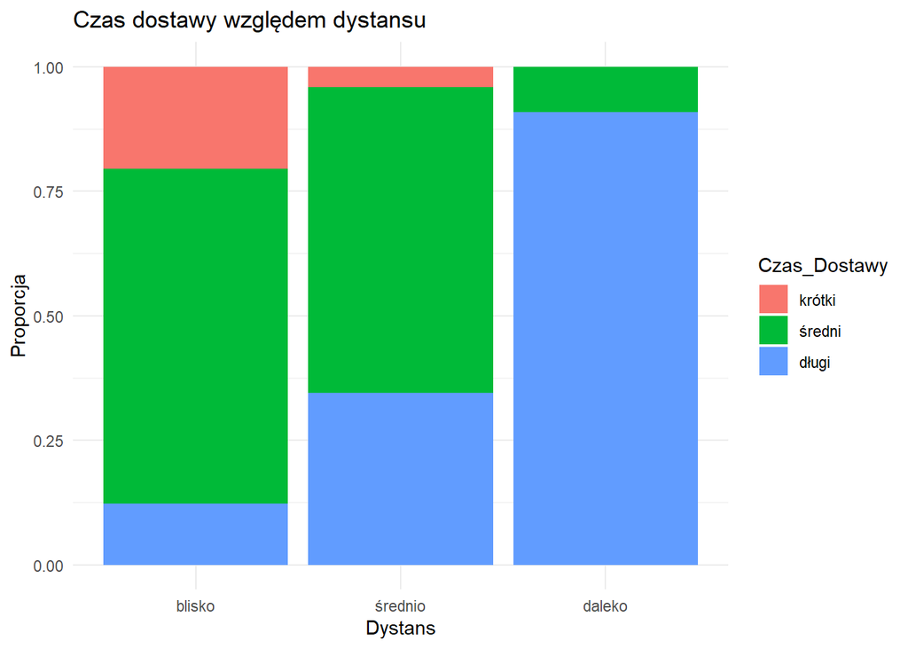

```r
# Wizualizacja: wpływ dystansu na czas dostawy
ggplot(dane_final, aes(x = Dystans, fill = Czas_Dostawy)) +
  geom_bar(position = "fill") +
  ylab("Proporcja") +
  theme_minimal() +
  ggtitle("Czas dostawy względem dystansu")
```

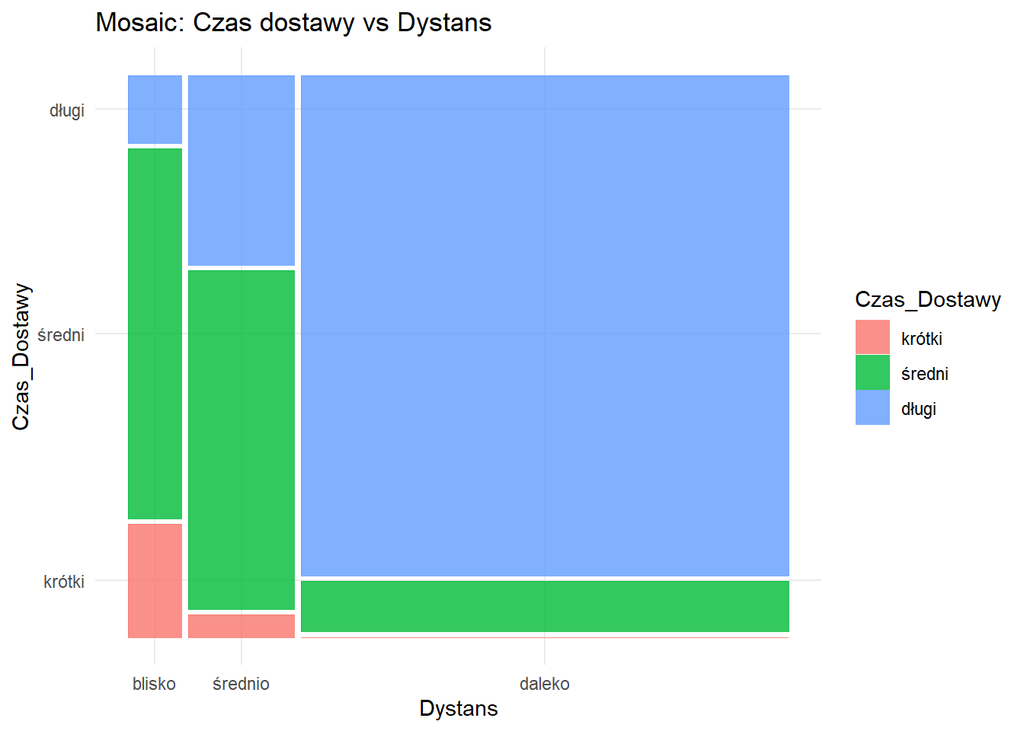

```r
# Wykres mozaikowy: Czas dostawy vs Dystans
ggplot(data = dane_final) +
  geom_mosaic(aes(weight = 1, x = product(Dystans), fill = Czas_Dostawy)) +
  labs(title = "Mosaic: Czas dostawy vs Dystans") +
  theme_minimal()
```

```r
# Budowa i dopasowanie modelu bayesowskiego oraz prezentacja tabel CPT
model_hc <- hc(dane_final)
rozkladprawdopodobienstw <- bn.fit(model_hc, data = dane_final)
print(rozkladprawdopodobienstw$Czas_Dostawy)
```

```
##
##   Parameters of node Czas_Dostawy (multinomial distribution)
##
## Conditional probability table:
##      krótki     średni      długi
## 0.02378256 0.22536806 0.75084938
```

```r
lapply(rozkladprawdopodobienstw, function(x) x$prob)
```

```
## $Weather
##      Clear      Foggy      Rainy      Snowy      Windy
## 0.48131370 0.11098528 0.21291053 0.09739524 0.09739524
##
## $Traffic_Level
##      High       Low    Medium
## 0.2049830 0.3929785 0.4020385
##
## $Time_of_Day
##  Afternoon    Evening    Morning      Night
## 0.29105323 0.30464326 0.31823330 0.08607022
##
## $Vehicle_Type
##      Bike       Car   Scooter
## 0.5107588 0.1947905 0.2944507
##
## $Doświadczenie
##   niskie  średnie  wysokie
## 0.198188 0.182333 0.619479
##
## $Czas_Dostawy
##     krótki     średni      długi
## 0.02378256 0.22536806 0.75084938
##
## $Dystans
##          Czas_Dostawy
## Dystans       krótki     średni      długi
##   blisko  0.71428571 0.24623116 0.01357466
##   średnio 0.28571429 0.44723618 0.07541478
##   daleko  0.00000000 0.30653266 0.91101056
```

```r
# Wnioskowanie probabilistyczne z użyciem gRain
fit <- bn.fit(model_hc, data = dane_final, method = "bayes")
grain_model <- as.grain(fit)
junction <- compile(grain_model)

# Znany długi czas dostawy — predykcja dystansu
querygrain(setEvidence(junction, nodes = "Czas_Dostawy", states = "długi"), nodes = "Dystans")
```

```
## $Dystans
## Dystans
##     blisko    średnio     daleko
## 0.01373534 0.07554439 0.91072027
```

```r
# Znany daleki dystans — predykcja typu pojazdu
querygrain(setEvidence(junction, nodes = "Dystans", states = "daleko"), nodes = "Vehicle_Type")
```

```
## $Vehicle_Type
## Vehicle_Type
##      Bike       Car   Scooter
## 0.5105581 0.1949472 0.2944947
```

```r
# Korki i pora dnia — predykcja doświadczenia kuriera
querygrain(setEvidence(junction,
                         nodes = c("Traffic_Level", "Time_of_Day"),
                         states = c("High", "afternoon")), nodes = "Doświadczenie")
```

```
## $Doświadczenie
## Doświadczenie
##    niskie   średnie   wysokie
## 0.1983409 0.1825038 0.6191554
```

```r
# Pogoda i poziom ruchu drogowego → Czas dostawy
evidence1 <- setEvidence(junction,
                         nodes = c("Weather", "Traffic_Level"),
                         states = c("Rainy", "High"))

querygrain(evidence1, nodes = "Czas_Dostawy")$Czas_Dostawy
```

```
## Czas_Dostawy
##     krótki     średni      długi
## 0.02413273 0.22549020 0.75037707
```

```r
# Typ pojazdu i doświadczenie kuriera → Czas dostawy
evidence2 <- setEvidence(junction,
                         nodes = c("Vehicle_Type", "Doświadczenie"),
                         states = c("Bike", "niskie"))

querygrain(evidence2, nodes = "Czas_Dostawy")$Czas_Dostawy
```

```
## Czas_Dostawy
##     krótki     średni      długi
## 0.02413273 0.22549020 0.75037707
```

```r
# Pora dnia i typ pojazdu → Poziom ruchu
evidence3 <- setEvidence(junction,
                         nodes = c("Time_of_Day", "Vehicle_Type"),
                         states = c("evening", "Car"))

querygrain(evidence3, nodes = "Traffic_Level")$Traffic_Level
```

```
## Traffic_Level
##      High       Low    Medium
## 0.2051282 0.3929110 0.4019608
```

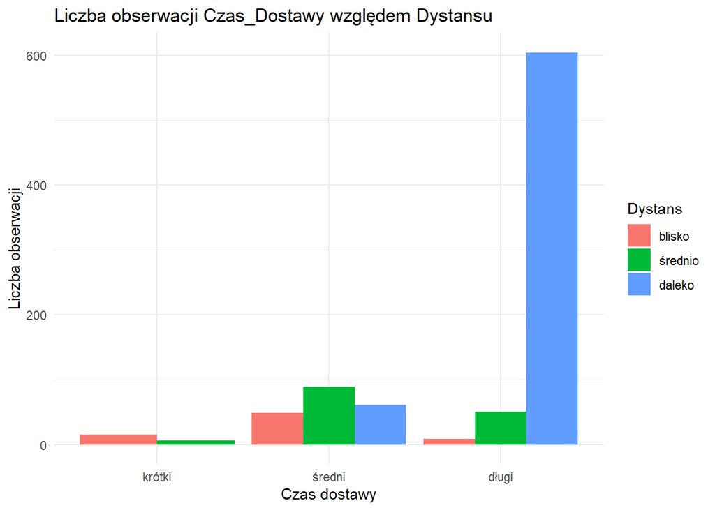

```r
# Wizualizacja rozkładów warunkowych — wykresy słupkowe
ggplot(dane_final, aes(x = Czas_Dostawy, fill = Dystans)) +
  geom_bar(position = "dodge") +
  labs(title = "Liczba obserwacji Czas_Dostawy względem Dystansu",
       x = "Czas dostawy",
       y = "Liczba obserwacji") +
  theme_minimal()
```

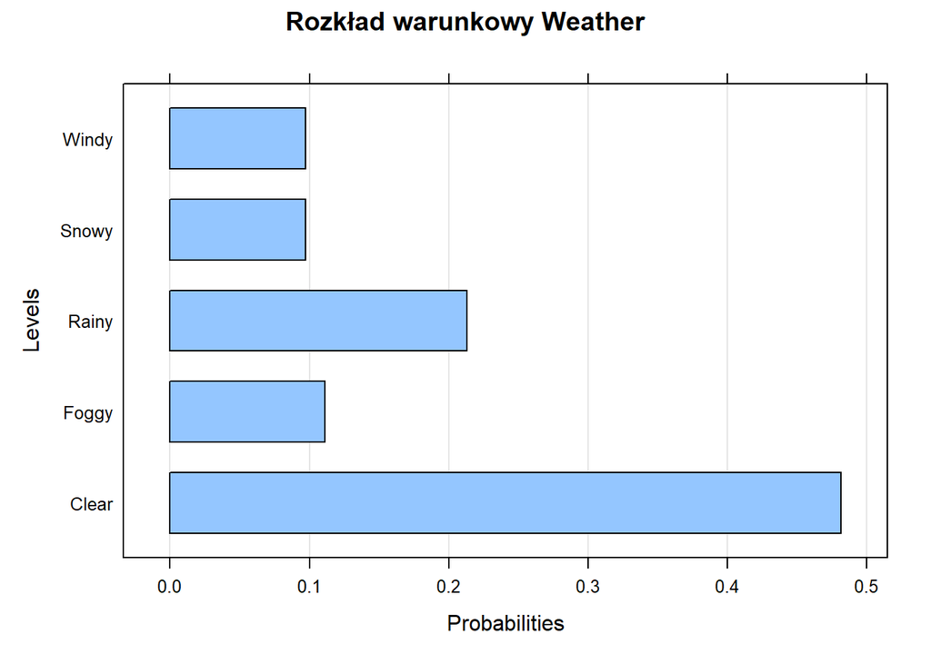

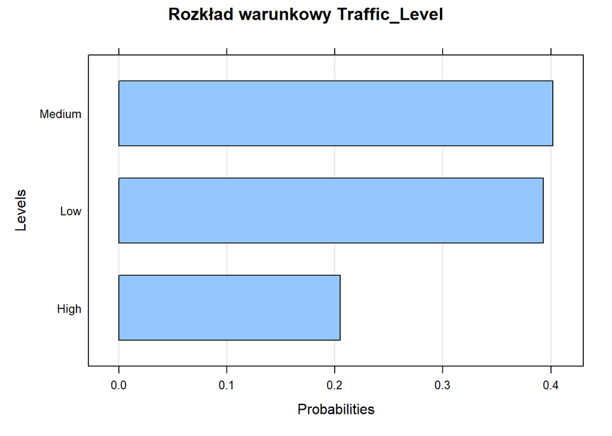

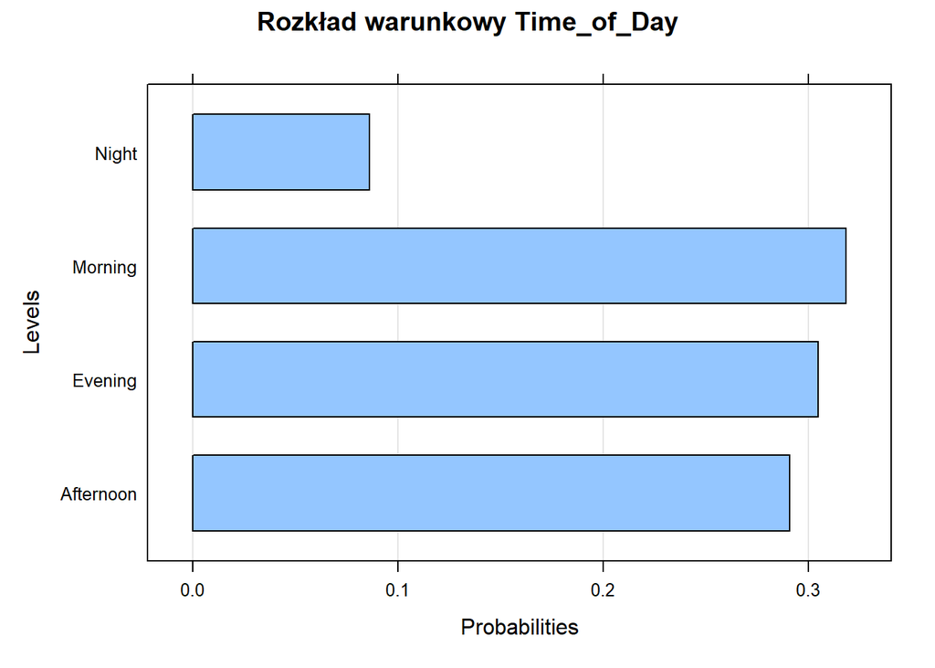

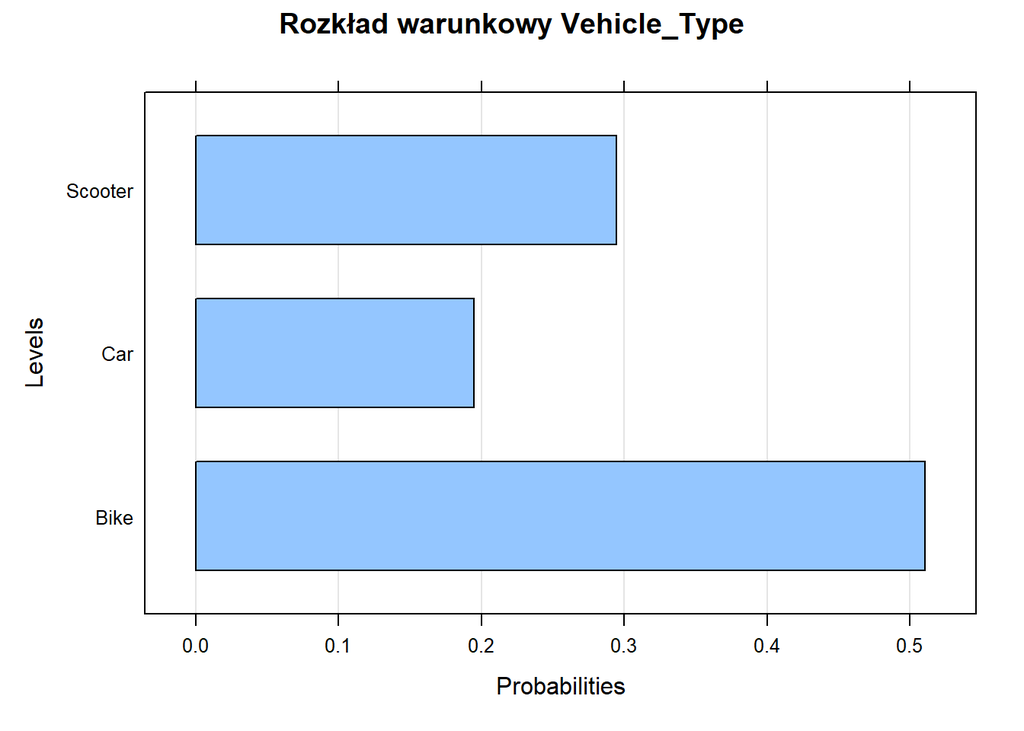

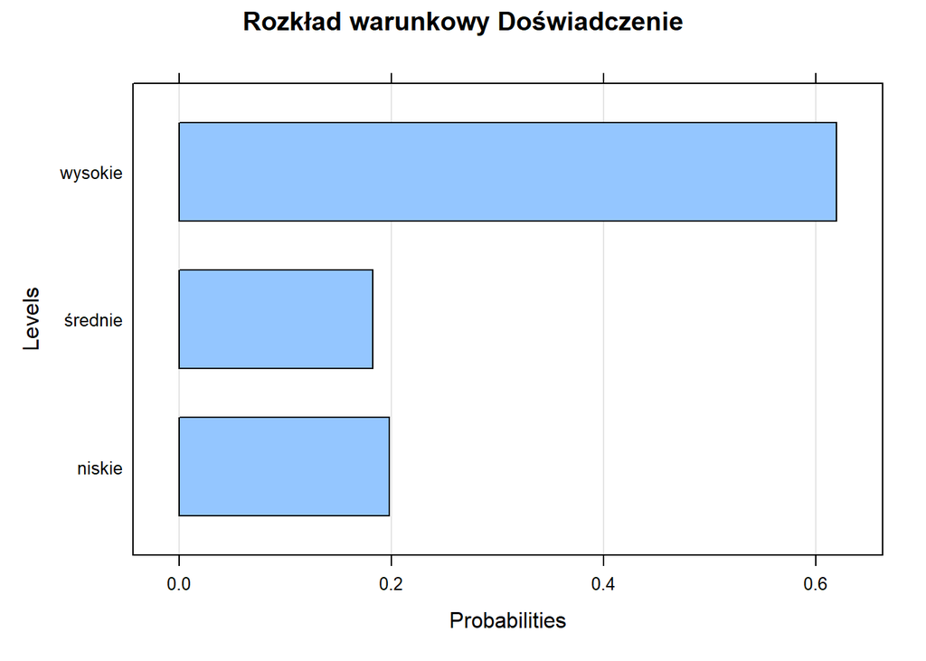

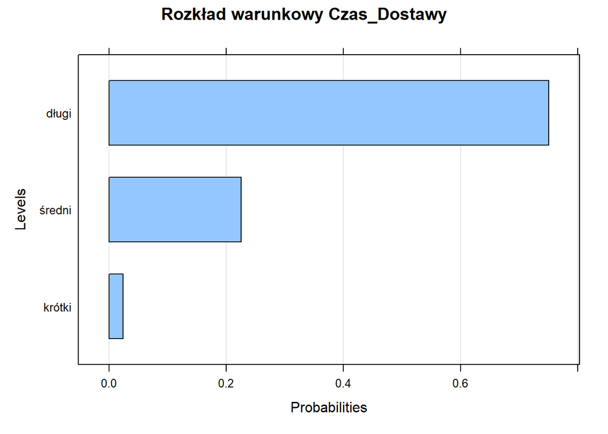

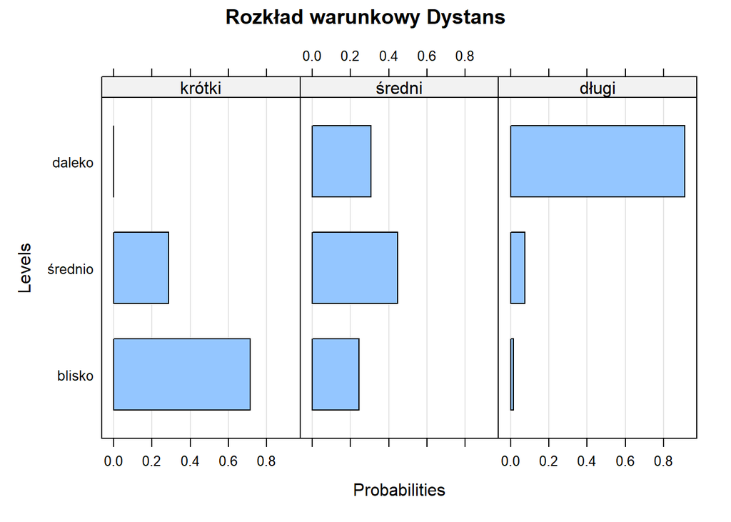

```r
# Wykresy rozkładów warunkowych dla poszczególnych zmiennych
for (var in names(rozkladprawdopodobienstw)) {
  bn.fit.barchart(rozkladprawdopodobienstw[[var]], main = paste("Rozkład warunkowy", var))
}
```

# Wnioski

### Z użyciem pakietu gRain przeprowadzono wnioskowanie probabilistyczne, które pozwoliło na przewidywanie zmiennych ukrytych przy zadanych wartościach innych. Przykładowe wyniki:

- Jeżeli wiemy, że czas dostawy był długi, to z prawdopodobieństwem 91% dostawa była na daleki dystans.
- Jeśli dystans był daleki, to największe prawdopodobieństwo (ok. 51%) przypisane jest wykorzystaniu roweru jako środka transportu.
- Dla sytuacji: duży ruch i popołudniowa pora — najbardziej prawdopodobny poziom doświadczenia kuriera to wysokie.

### Przeprowadzono testy niezależności oraz obliczono miary wzajemnej informacji (mutual information), z których wynika:

- Istnieje silna zależność między dystansem a czasem dostawy, nawet po uwzględnieniu typu pojazdu (p < 2.2e-16).
- Ruch drogowy warunkowany porą dnia również ma wpływ na czas dostawy (p = 0.02382).
- Doświadczenie kuriera warunkowane ruchem drogowym wpływa istotnie na czas dostawy (p = 0.0447).
- Nie stwierdzono istotnej zależności między dystansem a doświadczeniem kuriera (p = 0.8657) ani między typem pojazdu a czasem dostawy w warunkowaniu na Traffic + Time (p = 0.6818).

### Wnioski końcowe

- Najsilniejszym determinantem długiego czasu dostawy jest daleki dystans, co było intuicyjne.
- Wbrew oczekiwaniom, typ pojazdu oraz doświadczenie kuriera mają ograniczony wpływ na przewidywanie czasu dostawy w kontekście innych zmiennych.
- Sieci bayesowskie okazały się efektywnym narzędziem do modelowania zależności i wnioskowania probabilistycznego w kontekście usług dostawczych.
- Model może być rozszerzony lub zastosowany praktycznie do oceny ryzyka opóźnień, planowania tras, alokacji kurierów czy szacowania SLA (Service-Level Agreement).